# Diaphragm FACS Notebook

Specify the tissue of interest, run the boilerplate code which sets up the functions and environment, load the tissue object.

```
[1] "Scaling data matrix"
```

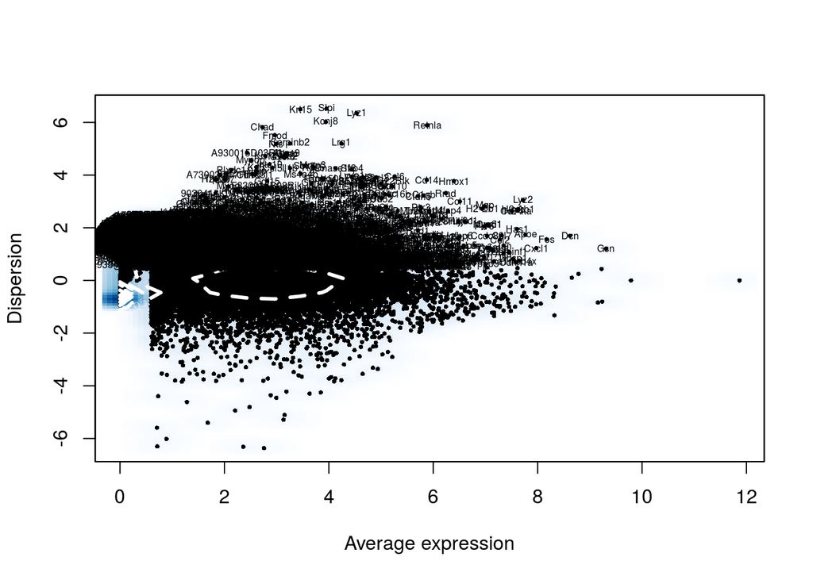

```r
tissue_of_interest = "Diaphragm"
library(here)
source(here("00_data_ingest", "02_tissue_analysis_rmd", "boilerplate.R"))
tiss <- load_tissue_facs(tissue_of_interest)
```

Visualize top genes in principal components

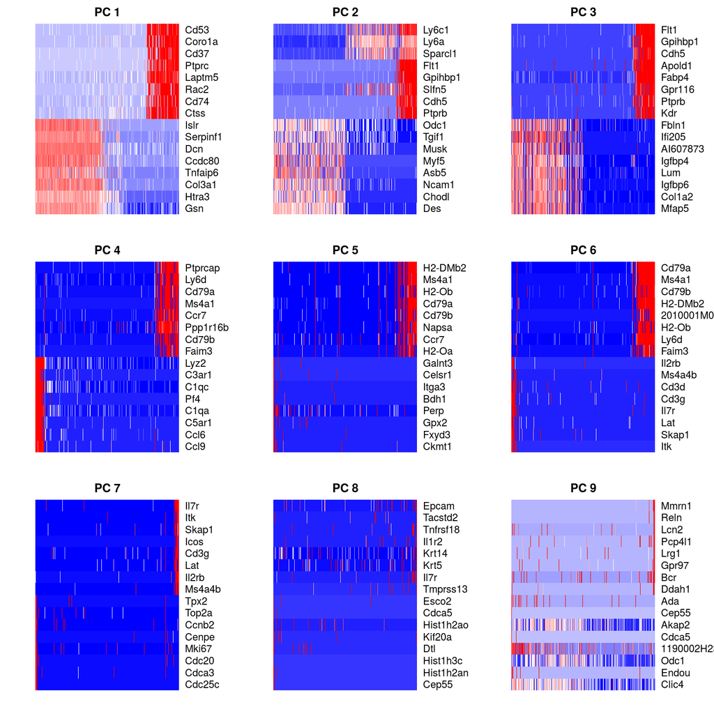

```r
col.use = CustomPalette(low = "blue", high = "red", mid = "white", k = 50)
PCHeatmap(object = tiss, pc.use = 1:9, cells.use = 500, do.balanced = T,
          label.columns = F, col.use = col.use, num.genes = 16)
```

Visualize top genes in principal components Later on (in FindClusters and TSNE) you will pick a number of principal components to use. This has the effect of keeping the major directions of variation in the data and, ideally, supressing noise. There is no correct answer to the number to use, but a decent rule of thumb is to go until the plot plateaus.

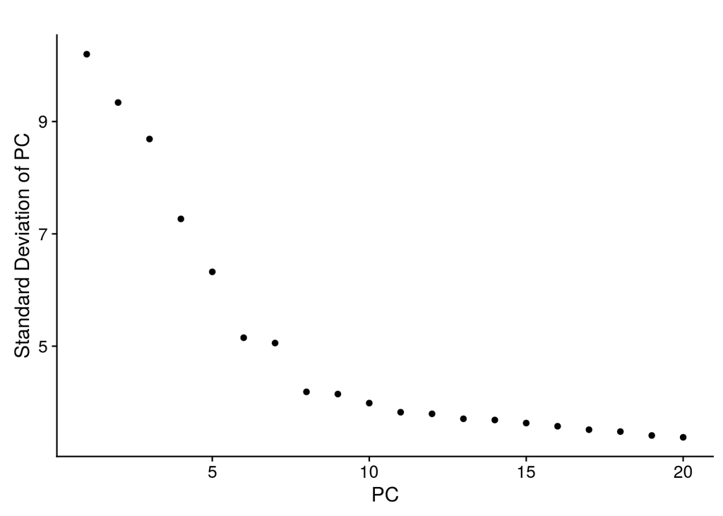

```r
PCElbowPlot(object = tiss)
```

Choose the number of principal components to use.

```r
n.pcs = 10
```

The clustering is performed based on a nearest neighbors graph. Cells that have similar expression will be joined together. The Louvain algorithm looks for groups of cells with high modularityâ“more connections within the group than between groups. The resolution parameter determines the scale. Higher resolution will give more clusters, lower resolution will give fewer. For the top-level clustering, aim to under-cluster instead of over-cluster. It will be easy to subset groups and further analyze them below. We use TSNE solely to visualize the data.

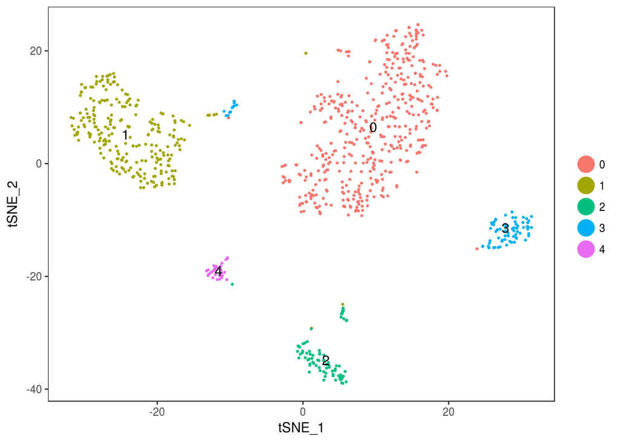

```r
used.res = 0.3
perplexity = 25
pt.size = 0.5
tiss <- FindClusters(object = tiss, reduction.type = "pca", dims.use = 1:n.pcs,
                     resolution = used.res, print.output = 0, save.SNN = T, force.recalc = T)
tiss <- RunTSNE(object = tiss, dims.use = 1:n.pcs, seed.use = 10, check_duplicates = F,
                perplexity = perplexity)
TSNEPlot(object = tiss, do.label = T, pt.size = pt.size)
```

Check expression of genes of interest.

```r
genes_to_check = c('Vcam1', 'Pdgfra', 'Ptprc', 'Pecam1')
cols.use <- c("grey", "red")

print (genes_to_check)
```

```
[1] "Vcam1"  "Pdgfra" "Ptprc"  "Pecam1"
```

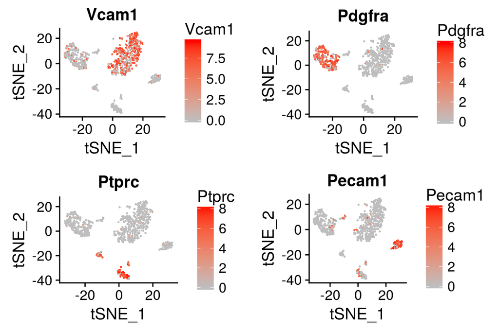

```r
FeaturePlot(tiss, genes_to_check, pt.size = pt.size, no.legend = FALSE, cols.use = cols.use, nCol = 2)
```

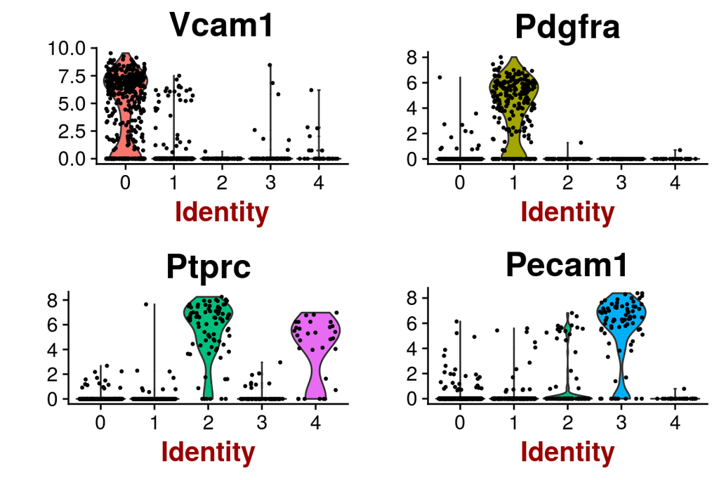

```r
VlnPlot(tiss, genes_to_check, point.size.use = pt.size, nCol = 2)
```

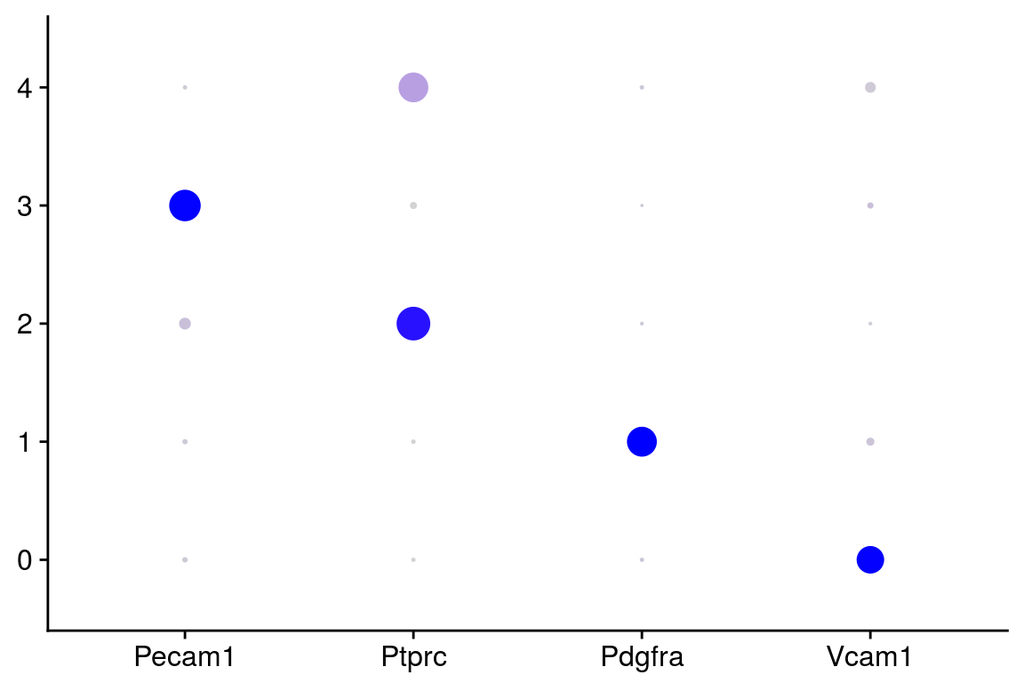

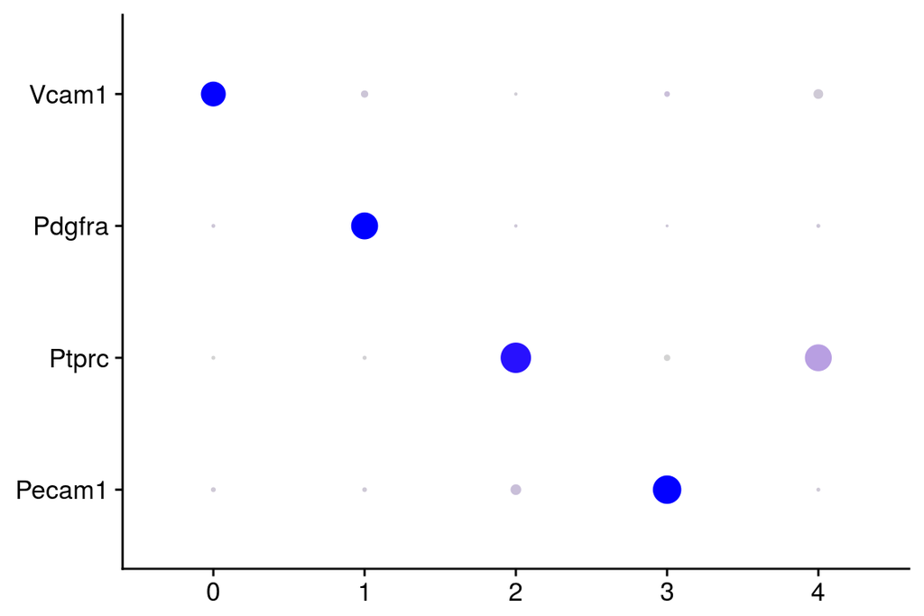

```r
DotPlot(tiss, genes_to_check, do.return=T) + coord_flip()
```

```r
# SC - subtypes
genes_to_check = c('Vcam1', 'Itga7', 'Calcr',
                   'Pax7', 'Pax3', 'Myod1', 'Myf5',
                   'Cxcr4', 'Sdc4', 'Itgb1', 'Cd34', 'Cd44' #, 'Myog'
                   )
print (genes_to_check)
```

```
 [1] "Vcam1" "Itga7" "Calcr" "Pax7"  "Pax3"  "Myod1" "Myf5"  "Cxcr4"
 [9] "Sdc4"  "Itgb1" "Cd34"  "Cd44"
```

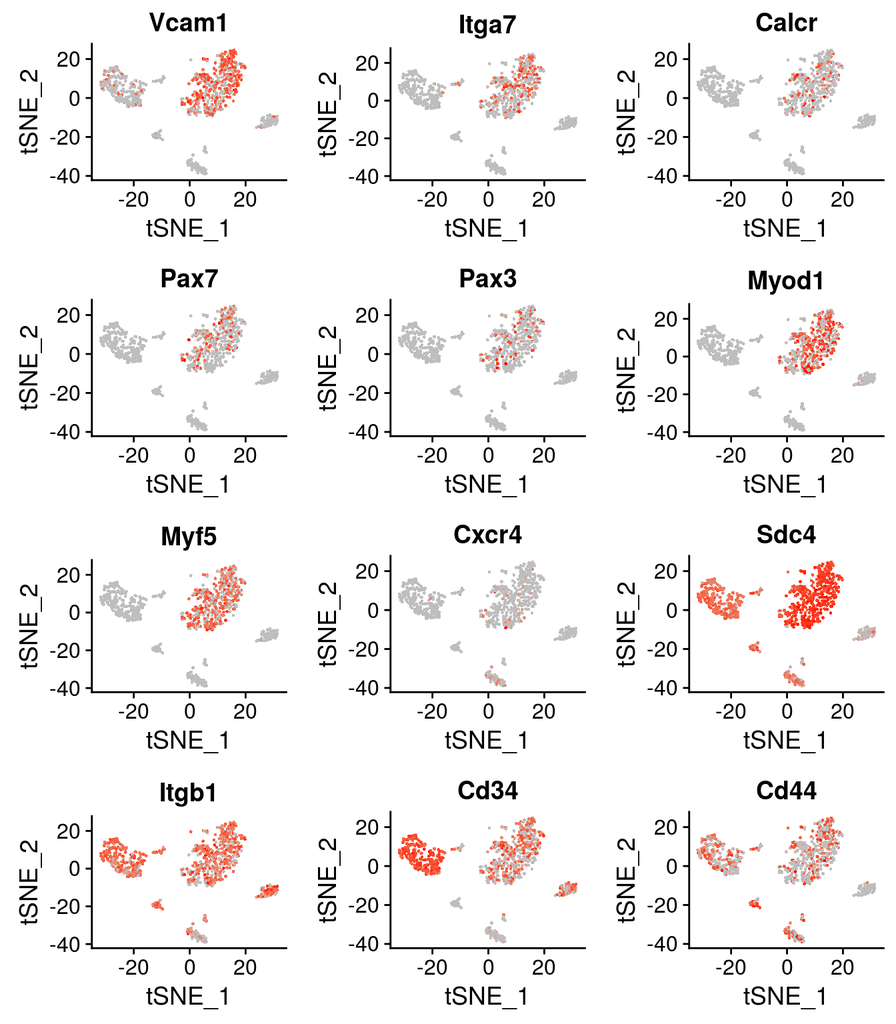

```r
FeaturePlot(tiss, genes_to_check, pt.size = pt.size, cols.use = cols.use, nCol = 3)
```

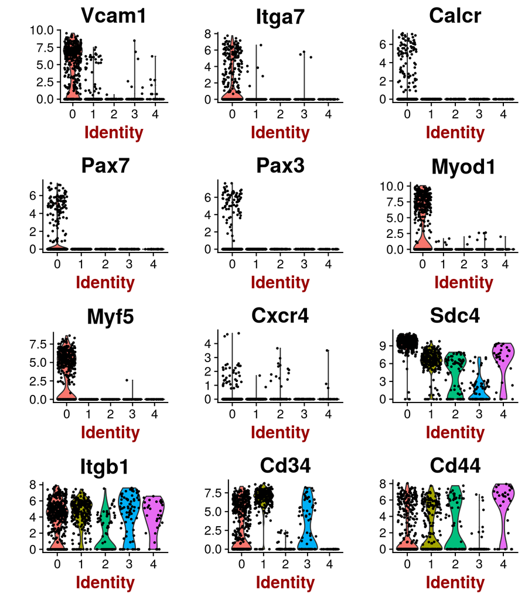

```r
VlnPlot(tiss, genes_to_check, point.size.use = pt.size, nCol = 3)
```

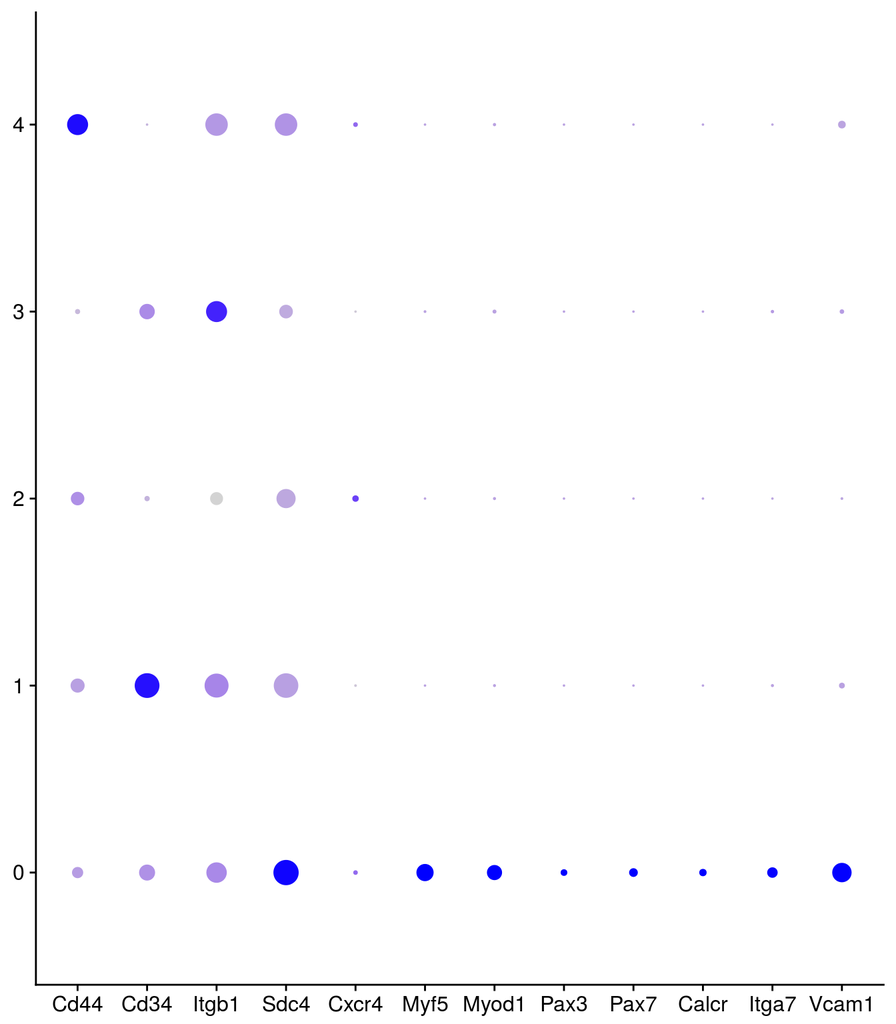

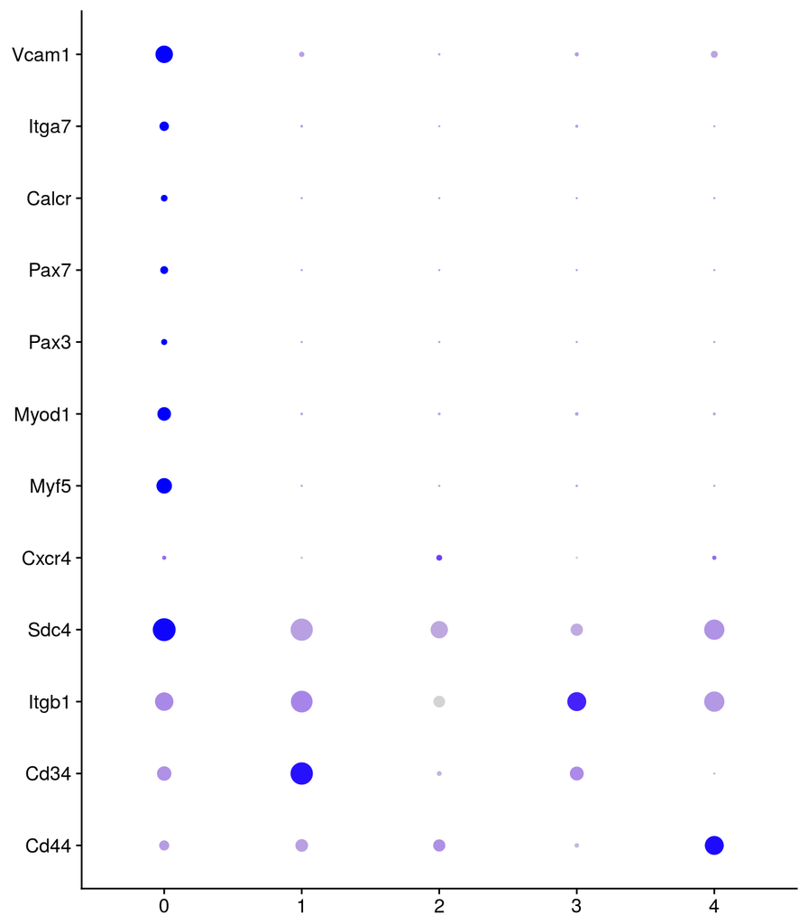

```r
DotPlot(tiss, genes_to_check, do.return=T) + coord_flip()
```

```r
# CD45 - blood subtypes
genes_to_check = c('Ptprc',
                   'Cd3d', #T-cell
                   'Vpreb3', #naive B-cells
                   'Cd19', 'Cd69', 'Cd79a', 'Cd79b', #differentiated B cells
                   'Klrb1b', 'Foxp3', # NK-cells
                   'Itgam', 'Fcer1g', 'C1qa' #macrophages and mast cells
                   #, 'Ly6g6d',
)
print (genes_to_check)
```

```
 [1] "Ptprc"  "Cd3d"   "Vpreb3" "Cd19"   "Cd69"   "Cd79a"  "Cd79b"
 [8] "Klrb1b" "Foxp3"  "Itgam"  "Fcer1g" "C1qa"
```

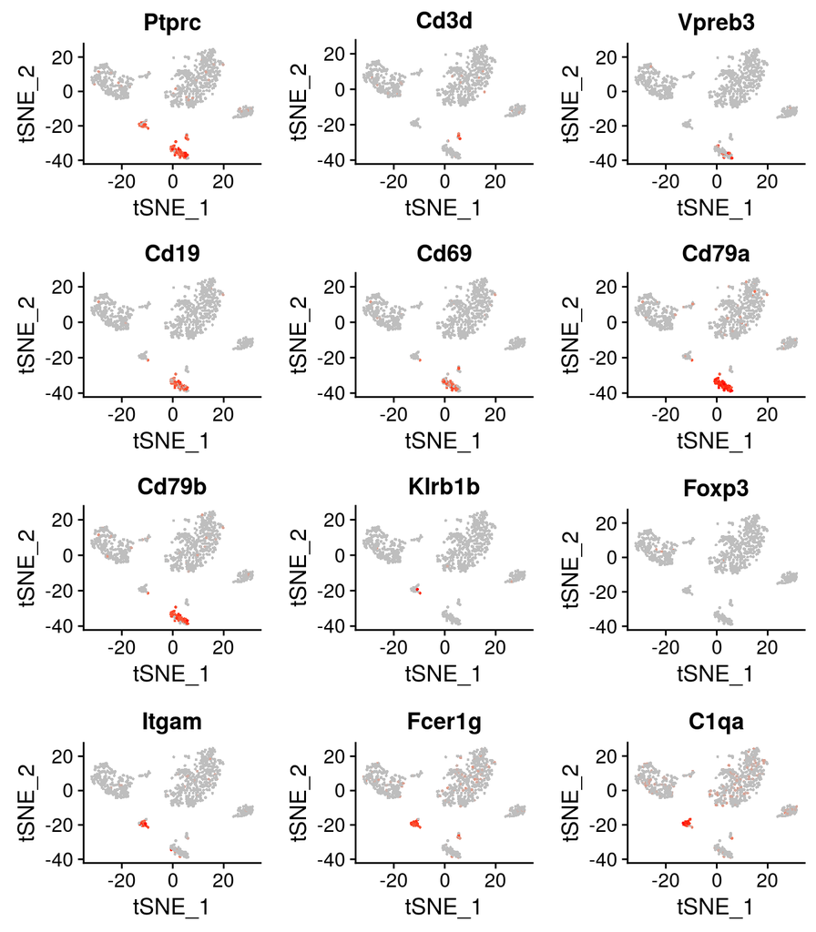

```r
FeaturePlot(tiss, genes_to_check, pt.size = pt.size, cols.use = cols.use, nCol = 3)
```

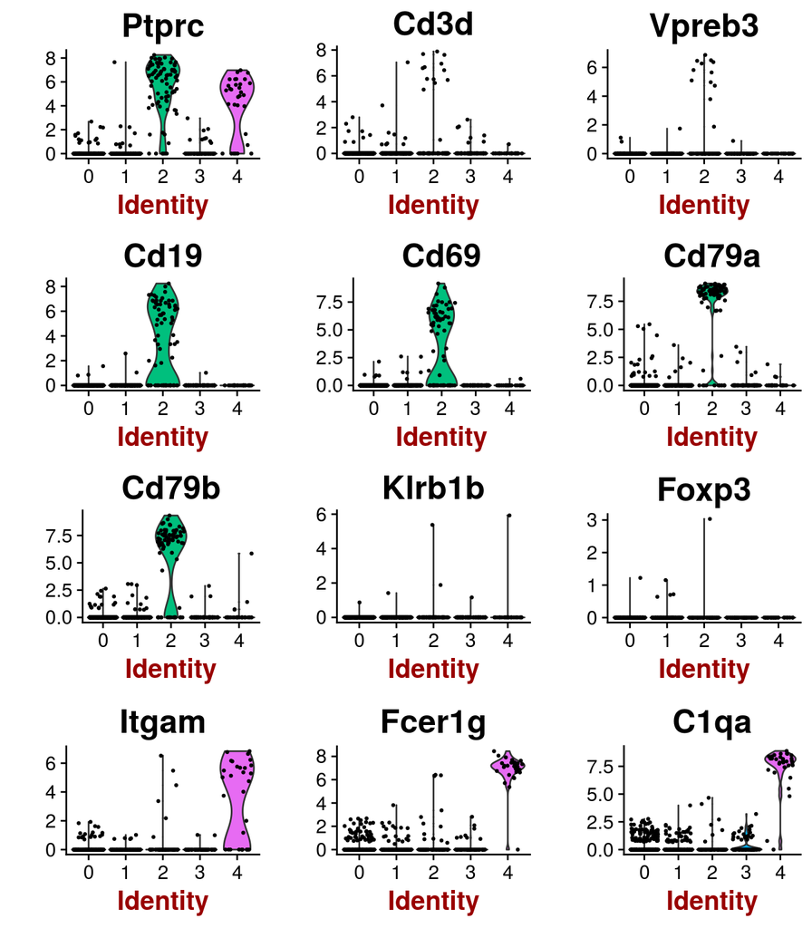

```r
VlnPlot(tiss, genes_to_check, point.size.use = pt.size, nCol = 3)
```

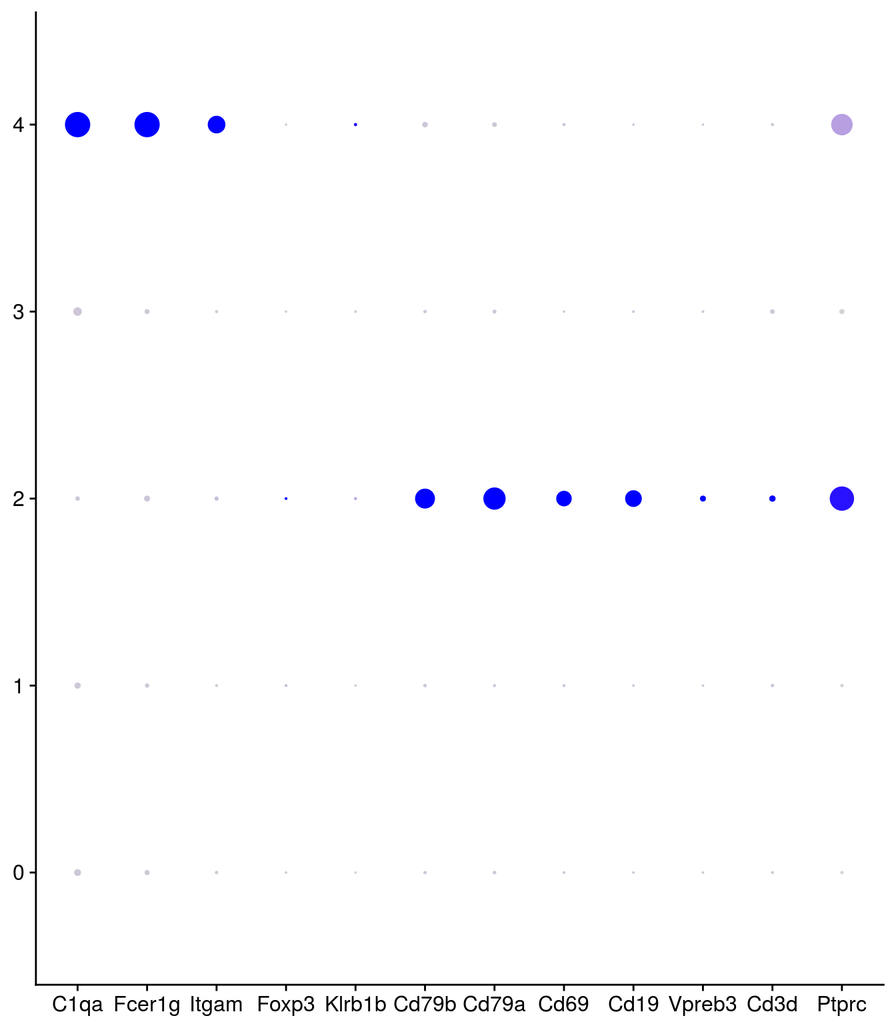

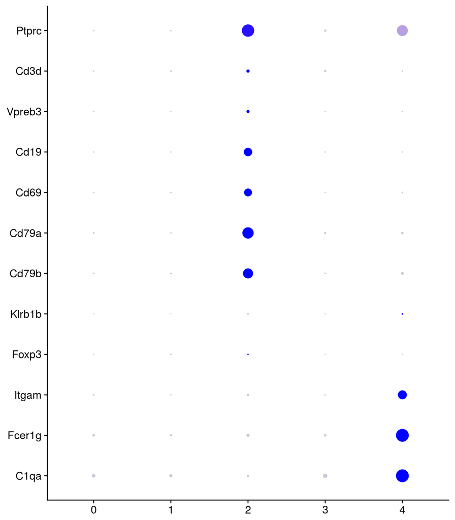

```r
DotPlot(tiss, genes_to_check, do.return=T) + coord_flip()
```

```r
# CD31 - endothelial subtypes
genes_to_check = c('Pecam1' #, 'Vegfa', 'Cd34', 'Ptprc', 'Icam1' #, 'Dysf' #'Rapgef3', 'Vim', 'Cspg4'
)
print (genes_to_check)
```

```
[1] "Pecam1"
```

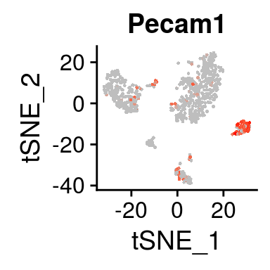

```r
FeaturePlot(tiss, genes_to_check, pt.size = pt.size, cols.use = cols.use, nCol = 1)
```

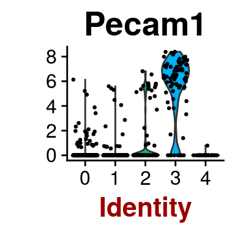

```r
VlnPlot(tiss, genes_to_check, point.size.use = pt.size, nCol = 1)
```

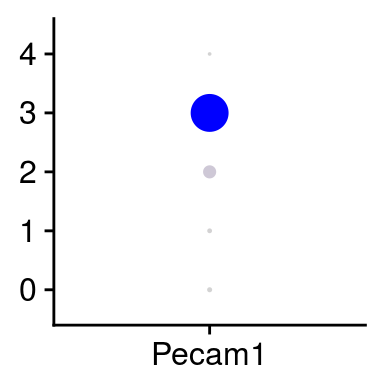

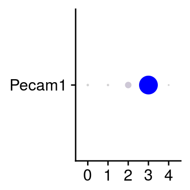

```r
DotPlot(tiss, genes_to_check, do.return=T) + coord_flip()
```

```r
# FAP -  subtypes
genes_to_check = c('Pdgfra' #'Atxn1' 'Dysf', 'Vim', 'Cspg4'
)
print (genes_to_check)
```

```
[1] "Pdgfra"
```

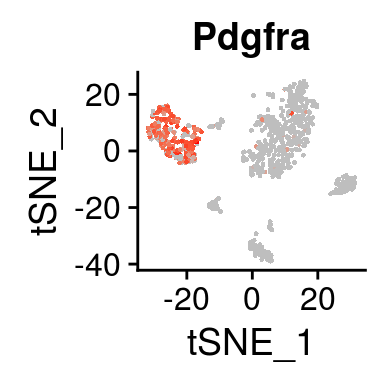

```r
FeaturePlot(tiss, genes_to_check, pt.size = pt.size, cols.use = cols.use, nCol = 1)
```

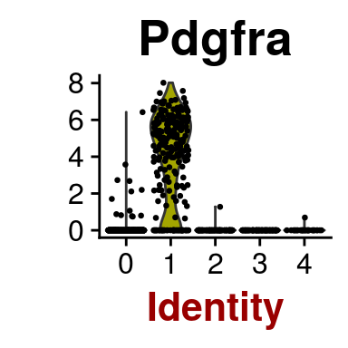

```r
VlnPlot(tiss, genes_to_check, point.size.use = pt.size, nCol = 1)
```

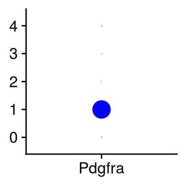

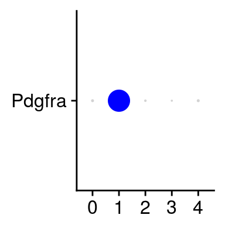

```r
DotPlot(tiss, genes_to_check, do.return=T) + coord_flip()
```

How big are the clusters?

```r
sum(table(tiss@ident))
```

```
[1] 870
```

```r
table(tiss@ident)
```

```
  0   1   2   3   4
439 241  81  78  31
```

```r
table(as.character(tiss@ident), as.character(tiss@meta.data$mouse.id))
```

```
    3_10_M 3_11_M 3_38_F 3_39_F
  0     53    173     69    144
  1     45     68     62     66
  2     21     22     17     21
  3      5     41      2     30
  4      4     15      7      5
```

Color by metadata, like plate barcode to check for batch effects.

```r
tiss@meta.data %>% names
```

```
 [1] "nGene"               "nReads"              "orig.ident"
 [4] "plate.barcode"       "mouse.id"            "tissue"
 [7] "subtissue"           "FACS.selection"      "mouse.sex"
[10] "percent.ercc"        "free_annotation"     "cell_ontology_class"
[13] "percent.ribo"        "res.0.3"
```

```
nGene

nReads

orig.ident

plate.barcode

mouse.id

tissue

subtissue

FACS.selection

mouse.sex

percent.ercc

free_annotation

cell_ontology_class

percent.ribo

res.0.3
```

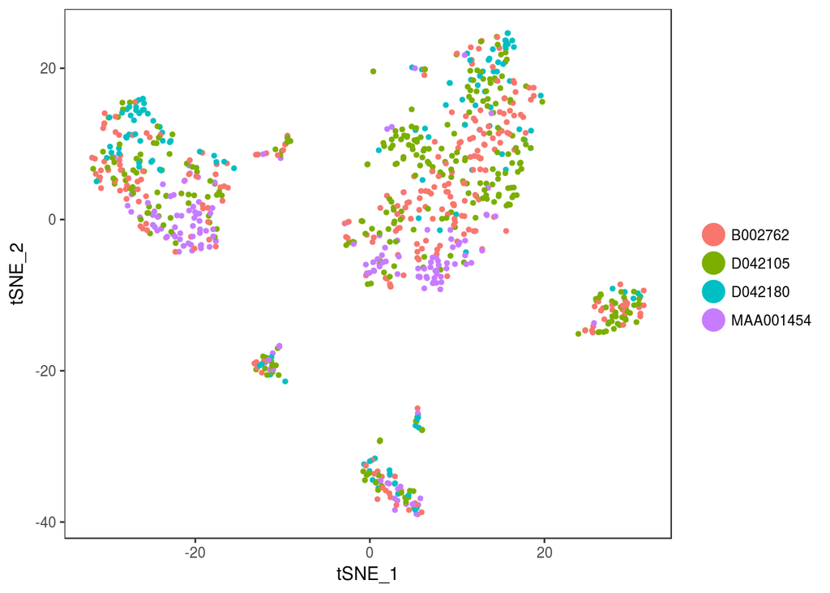

```r
TSNEPlot(object = tiss, do.return = TRUE, group.by = "plate.barcode")
```

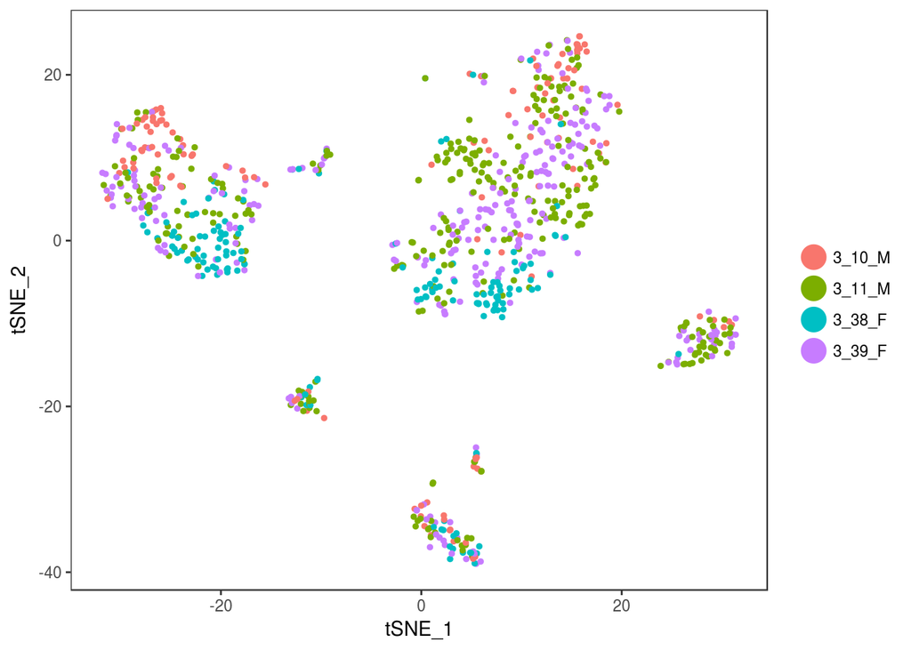

```r
TSNEPlot(object = tiss, do.return = TRUE, group.by = "mouse.id")
```

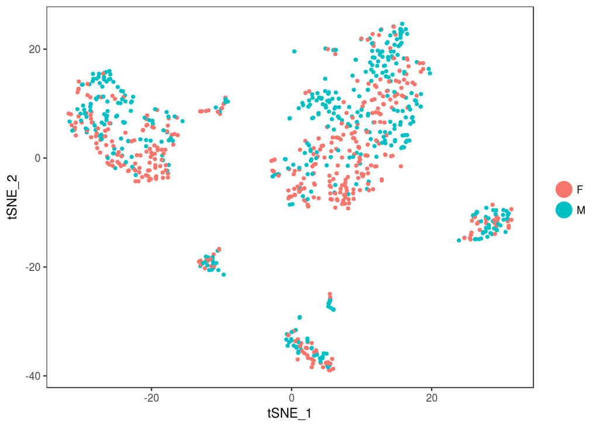

```r
TSNEPlot(object = tiss, do.return = TRUE, group.by = "mouse.sex")
```

```r
#tiss.markers <- FindAllMarkers(object = tiss, only.pos = TRUE, min.pct = 0.25,
#                               thresh.use = 0.25)
#tiss.markers %>% group_by(cluster) %>% top_n(24, avg_diff)
```

Assigning cell type identity to clusters

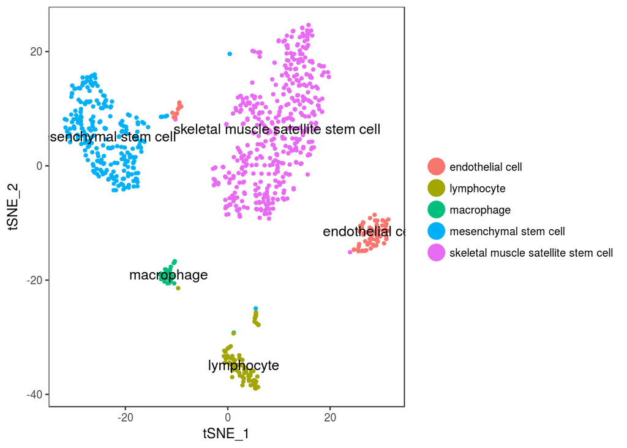

```r
# stash current cluster IDs
tiss <- StashIdent(object = tiss, save.name = "cluster.ids")

# enumerate current cluster IDs and the labels for them
cluster.ids <- c(0, 1, 2, 3, 4)
free_annotation <- c(NA, NA, NA, NA, NA)
cell_ontology_class <- c("skeletal muscle satellite stem cell", "mesenchymal stem cell",
                        "lymphocyte", "endothelial cell", "macrophage")

tiss = stash_annotations(tiss, cluster.ids, free_annotation, cell_ontology_class)

TSNEPlot(object = tiss, do.label = TRUE, group.by='cell_ontology_class')
```

```
[1] "Finished averaging RNA for cluster 0"
[1] "Finished averaging RNA for cluster 1"
[1] "Finished averaging RNA for cluster 2"
[1] "Finished averaging RNA for cluster 3"
[1] "Finished averaging RNA for cluster 4"
```

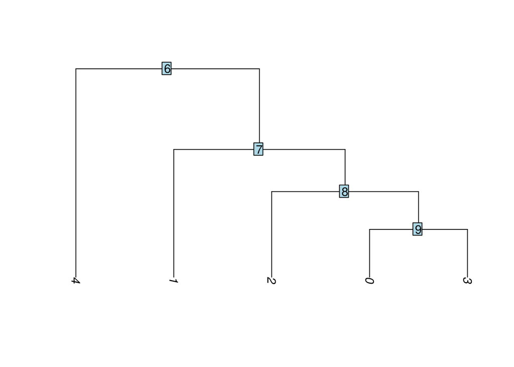

```r
tiss = BuildClusterTree(tiss)
```

When you save the annotated tissue, please give it a name.

```r
filename = here('00_data_ingest', '04_tissue_robj_generated',
                     paste0("facs_", tissue_of_interest, "_seurat_tiss.Robj"))
print(filename)
```

```
[1] "/home/rstudio/tabula-muris/00_data_ingest/04_tissue_robj_generated/facs_Diaphragm_seurat_tiss.Robj"
```

```r
save(tiss, file=filename)
```

Write the cell ontology and free annotations to CSV.

```r
save_annotation_csv(tiss, tissue_of_interest, "facs")
```